# 2022 Spring 2100 Final answers (33 points total)

## Butterflies

7.Data on butterflies from the United Kingdom is available @

```r
butterflies <- read.csv("https://docs.google.com/spreadsheets/d/e/2PACX-1vTGEITZzcvnfDMwdXGScOaAtzMQDtIKaFJXw7220J_efxvvPNrPLIt1qG1UP2bHiNZ2uJDZInOsZJTg/pub?gid=987706272&single=true&output=csv",
                        stringsAsFactors = T)
```

Use this data to investigate if there is a relationship between dry mass (estimated_dry_mass) and the maximum wing size (forewing_maximum) observed in species.

Make sure you include (6 pts)

- null hypothesis
- alternative hypothesis
- explanation for test you will use
- results from statistical test
- clear explanation of how results relate to your stated hypotheses

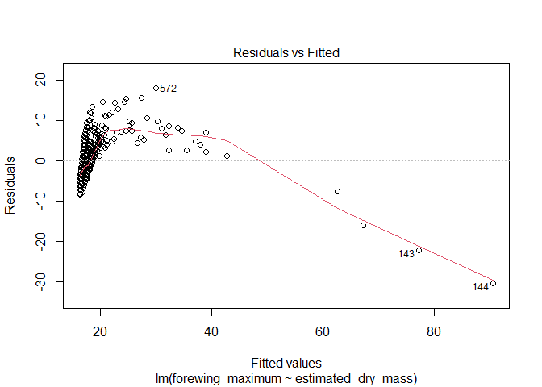

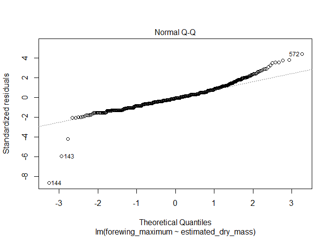

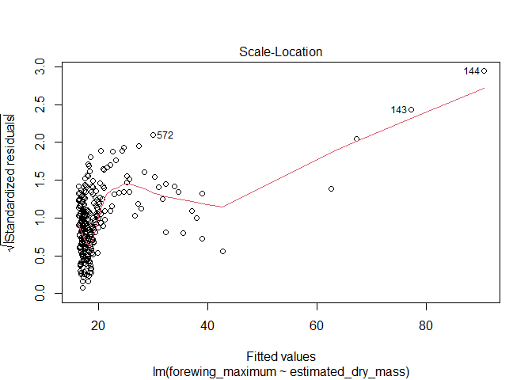

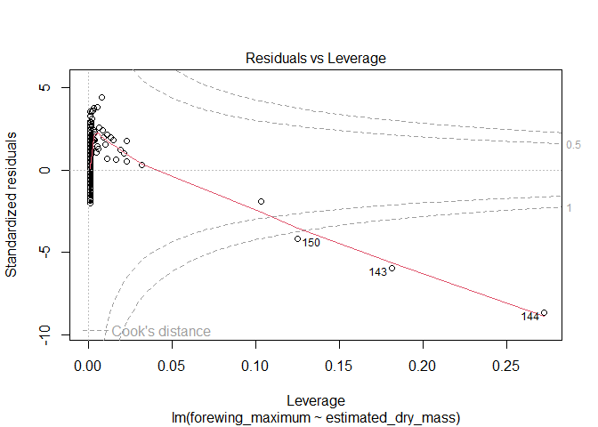

```r
butterfly_lm <- lm(forewing_maximum ~estimated_dry_mass, butterflies)
plot(butterfly_lm)
```

```r
summary(butterfly_lm)
```

```
##
## Call:
## lm(formula = forewing_maximum ~ estimated_dry_mass, data = butterflies)
##
## Residuals:
##      Min       1Q   Median       3Q      Max
## -30.4700  -2.4995  -0.2644   2.0810  18.1096
##
## Coefficients:
##                     Estimate Std. Error t value Pr(>|t|)
## (Intercept)        16.149434   0.152091  106.18   <2e-16 ***
## estimated_dry_mass  0.050911   0.001516   33.58   <2e-16 ***
## ---
## Signif. codes:  0 '***' 0.001 '**' 0.01 '*' 0.05 '.' 0.1 ' ' 1
##
## Residual standard error: 4.129 on 890 degrees of freedom
##   (76 observations deleted due to missingness)
## Multiple R-squared:  0.5589, Adjusted R-squared:  0.5584
## F-statistic:  1128 on 1 and 890 DF,  p-value: < 2.2e-16
```

```r
Anova(butterfly_lm, type = "III")
```

```
## Anova Table (Type III tests)
##
## Response: forewing_maximum
##                    Sum Sq  Df F value    Pr(>F)
## (Intercept)        192193   1 11274.7 < 2.2e-16 ***
## estimated_dry_mass  19226   1  1127.9 < 2.2e-16 ***
## Residuals           15171 890
## ---
## Signif. codes:  0 '***' 0.001 '**' 0.01 '*' 0.05 '.' 0.1 ' ' 1
```